# Wyznaczanie wielkości składki ubezbieczenia z wykorzystaniem uogólnionych modeli liniowych

Rozdział 2 pracy ‘Modelowanie ryzyka ubezpieczeń ja nie wiem, Piotrek’

07 lipiec 2022

Abstract

Model regresji logistycznej do oszacowania ryzyka udziału w kolizji drogowej w oparciu o cechy klienta. Opisany został stopniowy proces budowania modelu łącząc metody automatyczne z dotychczasową wiedzą i doświadczeniem. Oceniono wpływ cech na zmienną objaśnianą i ich interakcji. W ostatnim kroku decyzyjność modelu poddano ewaluacji pod kątem skuteczności w klasyfikacji. Porównano dodatnią i ujemną zdolność predykcyjną.

Proces modelowania rozpoczyna przyjrzenie się danym przygotowanym w etapie projektu “Przygotowanie danych”. W tej części cechy zostają poddane przekształceniu w oparciu o wnioski wyciągnięte w późniejszych etapach. Dla zachowania porządku myślowego przekształcenia, modyfikacje grup referencyjncyh zostają zawarte w tym akapicie. Etap modelowania oszacowania szansy wystąpienia kolizji drogowej i wystąpienia o odszkodowanie przez klienta w oparciu o dane dotyczące:  
- podstawowej metryki klienta  
- sytuacja w rodzinnaprywatnym,  
- statusu materialnego oraz pozycji społecznej klienta  
- historię ubezbieczenie samochodu klienta,  
Dostępne dane zostają ocenione w kontekście wpływu na ryzyko wystąpienia kolizji drogowej. Kolejne cechy zostały dobierane w oparciu o automatyczną selekcję w oparciu o wartości kryterium informacyjnego.

### Wczytanie danych

```r
dane <- read.csv("./dane/po_imputacji.csv", sep=';', encoding = "UTF-8", dec = ',')
dane <- dane[, -c(24)]
```

### Wstępne przetworzenie zmiennych

```
##    X.U.FEFF.           ID               KIDSDRIV           AGE        HOMEKIDS
##  Min.   :    0   Min.   :    63175   Min.   :0.0000   Min.   :16.00   0:6692
##  1st Qu.: 2574   1st Qu.:244390016   1st Qu.:0.0000   1st Qu.:39.00   1:1106
##  Median : 5147   Median :497054064   Median :0.0000   Median :45.00   2:1424
##  Mean   : 5147   Mean   :495649303   Mean   :0.1694   Mean   :44.84   3: 854
##  3rd Qu.: 7720   3rd Qu.:739230069   3rd Qu.:0.0000   3rd Qu.:51.00   4: 201
##  Max.   :10294   Max.   :999926368   Max.   :4.0000   Max.   :81.00   5:  18
##
##       YOJ            INCOME         PARENT1        HOME_VAL        MSTATUS
##  Min.   : 0.00   Min.   :     0   FAŁSZ :8956   Min.   :     0   FAŁSZ :4109
##  1st Qu.: 9.00   1st Qu.: 28722   PRAWDA:1339   1st Qu.:     0   PRAWDA:6186
##  Median :11.00   Median : 53739                 Median :159782
##  Mean   :10.47   Mean   : 61405                 Mean   :154522
##  3rd Qu.:13.00   3rd Qu.: 84622                 3rd Qu.:234997
##  Max.   :23.00   Max.   :367030                 Max.   :885282
##
##  GENDER          EDUCATION           OCCUPATION      TRAVTIME
##  F:5540   <High School:1512   Blue Collar :2391   Min.   :  5.00
##  M:4755   Bachelors   :2821   Clerical    :1630   1st Qu.: 22.00
##           High School :2950   Professional:1470   Median : 33.00
##           Masters     :2078   Manager     :1288   Mean   : 33.42
##           PhD         : 934   Lawyer      :1116   3rd Qu.: 44.00
##                               Student     : 898   Max.   :142.00
##                               (Other)     :1502
##    CAR_USE             BLUEBOOK          TIF           CAR_TYPE
##  Length:10295       Min.   : 1500   Min.   : 1.000   Length:10295
##  Class :character   1st Qu.: 9200   1st Qu.: 1.000   Class :character
##  Mode  :character   Median :14400   Median : 4.000   Mode  :character
##                     Mean   :15666   Mean   : 5.328
##                     3rd Qu.:20900   3rd Qu.: 7.000
##                     Max.   :69740   Max.   :25.000
##
##    RED_CAR        OLDCLAIM     CLM_FREQ   REVOKED        MVR_PTS
##  FAŁSZ :7326   Min.   :    0   0:6289   FAŁSZ :9035   Min.   : 0.000
##  PRAWDA:2969   1st Qu.:    0   1:1277   PRAWDA:1260   1st Qu.: 0.000
##                Median :    0   2:1491                 Median : 1.000
##                Mean   : 4032   3: 992                 Mean   : 1.709
##                3rd Qu.: 4646   4: 224                 3rd Qu.: 3.000
##                Max.   :57037   5:  22                 Max.   :13.000
##
##     CAR_AGE        CLAIM_FLAG                 URBANICITY      OG_DATA
##  Min.   : 0.000   FAŁSZ :7555   Highly Rural/ Rural:2071   Min.   :0.0000
##  1st Qu.: 3.000   PRAWDA:2740   Highly Urban/ Urban:8224   1st Qu.:0.0000
##  Median : 8.000                                            Median :1.0000
##  Mean   : 8.292                                            Mean   :0.7438
##  3rd Qu.:12.000                                            3rd Qu.:1.0000
##  Max.   :28.000                                            Max.   :1.0000
##
##  MVR_PTS_GRP OCCUPATION_GRP     AGE_tr        HOME_VAL_D
##  1:9540      0:4140         Min.   :   0.00   0:2906
##  2: 739      1:6155         1st Qu.:   9.00   1:7389
##  3:  16                     Median :  36.00
##                             Mean   :  74.09
##                             3rd Qu.: 100.00
##                             Max.   :1296.00
##
```

```
##      X.U.FEFF.             ID       KIDSDRIV            AGE       HOMEKIDS
##      "integer"      "integer"      "integer"      "integer"      "integer"
##            YOJ         INCOME        PARENT1       HOME_VAL        MSTATUS
##       "double"       "double"      "integer"       "double"      "integer"
##         GENDER      EDUCATION     OCCUPATION       TRAVTIME        CAR_USE
##      "integer"      "integer"      "integer"      "integer"    "character"
##       BLUEBOOK            TIF       CAR_TYPE        RED_CAR       OLDCLAIM
##      "integer"      "integer"    "character"      "integer"      "integer"
##       CLM_FREQ        REVOKED        MVR_PTS        CAR_AGE     CLAIM_FLAG
##      "integer"      "integer"      "integer"       "double"      "integer"
##     URBANICITY        OG_DATA    MVR_PTS_GRP OCCUPATION_GRP         AGE_tr
##      "integer"      "integer"      "integer"      "integer"       "double"
##     HOME_VAL_D
##      "integer"
```

### Podział na dwa zbiory - treningowy i uczący.

Za pomocą generatora liczb w rozkładzie jednorodnym, losujemy 70% wszystkich rekordów tabeli i przypisujemy je do zestawu treningowe. Pozostałe 30% zostaje przypisanych do zestawu testowego, który posłuży do ewaluacji skuteczności naszego modelu. Po przeprowadzeniu podziału, weryfikujemy czy balans klas został zachowany w odniesieniu do oryginalnego zestawu danych.

```r
# Losowanie na wczesnym etapie, Podział na dane treningowe i testowe
n <- nrow(dane)
liczby_losowe <- sample(c(1:n), round(0.7*n), replace = FALSE)
dane_uczacy <- dane[liczby_losowe,]
dane_testowy <- dane[-liczby_losowe,]

# Przeliczenie
table(dane_testowy$CLAIM_FLAG) / nrow(dane_testowy)
```

```
##
##     FAŁSZ    PRAWDA
## 0.7258012 0.2741988
```

```r
table(dane_uczacy$CLAIM_FLAG) / nrow(dane_uczacy)
```

```
##
##     FAŁSZ    PRAWDA
## 0.7373022 0.2626978
```

### Analiza danych pod kątem wystąpienia szkody / kolizji drogowej

**Pierwsze wnioski i hipotezy:** - Zamożni rzadziej powodują wypadki, ale tylko do przedziału 22 018USD, dla kolejnych grup dochodowych liczba wypadkóW wzrasta.

- Mężczyzni częściej powodują wypadki (pytanie czy to istotna różnica).
- Zdecydowanie więcej wypadków powodują osoby niebędące rodzicami.
- Osoby będące w dolnych grupach wiekowych powodują więcej kolizji, ta tendencja spada wraz z wiekiem aż do grupy 48-55lat i następnie wzrasta w grupach.
- Czy możemy sprawdzic czy największe prawdopodobieństwo wystąpeinia szkody zachodzi w przypadku podróży średnio-długich (45-60min).
- Osoby, które otrzymały w przeszłości punkty karne, zdecydowanie częściej są uczestnikami kolizji drogowych.
- Widoczna jest również zależność pomiędzy wiekiem samochodu a częstościa występowania zdarzenia, wraz z wiekiem samochodu, maleje szansa na udział kolizji drogowej.
- Studenci i osoby nisko wykwalifikowane rzadziej biorą udział w kolizjach drogowych.
- Liczba dzieci wpływa na ryzyko udziału w kolizji drogowej przez rodziców.
- Liczba lat bycia ubezpieczonym w firmie może wpływać na nizsze ryzyko.
- Jednostka osadnicza - zagęszczenie ruchu drogowego może zwiększać ryzyko udziału w kolizji drogowej.
- Charakter wykorzystywania samochodu - prywatny czy też w celach komercyjnych.

#### Iteracyjne budowanie

Weryfikacja wpływu poszczególnych zmiennych na objaśnianą.

```r
cols <- as.vector(colnames(dane[,-c(26,23)]))

for (c in cols[3:length(cols)]){

  if (c != 'CLAIM_FLAG'){

    m <- glm(as.formula(paste('CLAIM_FLAG', "~", c)), data = dane_uczacy, family = binomial)
    w_test <- waldtest(m)

  if (w_test$`Pr(>F)`[2] < 0.05){
      print(paste('istotna',c ,'pvalue:', format(w_test$`Pr(>F)`[2],  scientific = TRUE))[1])

  } else{
      print(paste('nieistotna',c,'pvalue:', round(w_test$`Pr(>F)`[2], 2) ))
  }
  }
  gc() #garbage cleaner
}
```

```
## [1] "istotna KIDSDRIV pvalue: 4.677264e-19"
## [1] "istotna AGE pvalue: 1.744944e-18"
## [1] "istotna HOMEKIDS pvalue: 1.751219e-29"
## [1] "istotna YOJ pvalue: 2.950484e-06"
## [1] "istotna INCOME pvalue: 1.05994e-30"
## [1] "istotna PARENT1 pvalue: 6.908432e-38"
## [1] "istotna HOME_VAL pvalue: 1.56426e-45"
## [1] "istotna MSTATUS pvalue: 1.353649e-23"
## [1] "nieistotna GENDER pvalue: 0.07"
## [1] "istotna EDUCATION pvalue: 8.411853e-37"
## [1] "istotna OCCUPATION pvalue: 1.024975e-45"
## [1] "istotna TRAVTIME pvalue: 5.449495e-06"
## [1] "istotna CAR_USE pvalue: 3.150047e-31"
## [1] "istotna BLUEBOOK pvalue: 6.719778e-20"
## [1] "istotna TIF pvalue: 5.876252e-09"
## [1] "istotna CAR_TYPE pvalue: 1.409558e-23"
## [1] "nieistotna RED_CAR pvalue: 0.13"
## [1] "istotna OLDCLAIM pvalue: 3.832462e-28"
## [1] "istotna CLM_FREQ pvalue: 1.385857e-78"
## [1] "istotna REVOKED pvalue: 6.21717e-43"
## [1] "istotna CAR_AGE pvalue: 2.24836e-21"
## [1] "nieistotna OG_DATA pvalue: 0.13"
## [1] "istotna MVR_PTS_GRP pvalue: 1.767158e-37"
## [1] "istotna OCCUPATION_GRP pvalue: 7.387777e-31"
## [1] "istotna AGE_tr pvalue: 2.159386e-22"
## [1] "istotna HOME_VAL_D pvalue: 1.275537e-31"
```

#### Proces budowania kolejnych zmiennych

### Model 1 - dochód

W pierwszym modelu stawiamy hipotezę, że istnieje zależność pomiędzy wzrostem dochodu a liczba kolizji.

```r
m1 <- glm(CLAIM_FLAG~INCOME, data = dane_uczacy, family = binomial)
summary(m1)
```

```
##
## Call:
## glm(formula = CLAIM_FLAG ~ INCOME, family = binomial, data = dane_uczacy)
##
## Deviance Residuals:
##     Min       1Q   Median       3Q      Max
## -0.9378  -0.8248  -0.7284   1.4376   2.4769
##
## Coefficients:
##               Estimate Std. Error z value Pr(>|z|)
## (Intercept) -5.936e-01  4.454e-02  -13.33   <2e-16 ***
## INCOME      -7.579e-06  6.549e-07  -11.57   <2e-16 ***
## ---
## Signif. codes:  0 '***' 0.001 '**' 0.01 '*' 0.05 '.' 0.1 ' ' 1
##
## (Dispersion parameter for binomial family taken to be 1)
##
##     Null deviance: 8299.3  on 7205  degrees of freedom
## Residual deviance: 8151.4  on 7204  degrees of freedom
## AIC: 8155.4
##
## Number of Fisher Scoring iterations: 4
```

**Wniosek**  
Analizując parametr strukturalny $\beta_1$, wnioskujemy, że zachodzi odwrotna zależność pomiędzy dochodem a szansą wystąpienia kolizji(Destymulanta).

### Model 2 - liczba przepracowanych lat w miejscu pracy

W drugim modelu stawiamy hipotezę, że istnieje zależność pomiędzy liczbą przepracowanych lat a liczba kolizji. Czy

```r
m2 <- glm(CLAIM_FLAG ~ INCOME + YOJ, data = dane_uczacy, family = binomial)
summary(m2)
```

```
##
## Call:
## glm(formula = CLAIM_FLAG ~ INCOME + YOJ, family = binomial, data = dane_uczacy)
##
## Deviance Residuals:
##     Min       1Q   Median       3Q      Max
## -0.9571  -0.8206  -0.7274   1.4150   2.4724
##
## Coefficients:
##               Estimate Std. Error z value Pr(>|z|)
## (Intercept) -5.431e-01  7.198e-02  -7.545 4.51e-14 ***
## INCOME      -7.384e-06  6.887e-07 -10.721  < 2e-16 ***
## YOJ         -5.963e-03  6.708e-03  -0.889    0.374
## ---
## Signif. codes:  0 '***' 0.001 '**' 0.01 '*' 0.05 '.' 0.1 ' ' 1
##
## (Dispersion parameter for binomial family taken to be 1)
##
##     Null deviance: 8299.3  on 7205  degrees of freedom
## Residual deviance: 8150.6  on 7203  degrees of freedom
## AIC: 8156.6
##
## Number of Fisher Scoring iterations: 4
```

**Wniosek**  
Analizując parametr strukturalny $\beta_1$, wnioskujemy, że nie występuje istotna zależność pomiędzy liczbą przepracowanych lat a szansą wystąpienia kolizji w modelu ze zmienną dochód. Parametr strukturalny *YOI* zweryfikowany testem Walda jest nieistotny statystycznie modelu m2.

### Model 3 - fakt bycia samotnym rodzicem

W trzecim modelu stawiamy hipotezę, że istnieje zależność pomiędzy faktem bycia samotnym rodzicem a zwiększonym ryzykiem udziału w kolizji. Zmienna *PARENT1* jest zmienną dychotomicza, więc weryfikujemy tylko czy osoba jest rodzicem, czy też nie.

```r
m3 <- glm(CLAIM_FLAG~INCOME+PARENT1, data = dane_uczacy, family = binomial)
summary(m3)
```

```
##
## Call:
## glm(formula = CLAIM_FLAG ~ INCOME + PARENT1, family = binomial,
##     data = dane_uczacy)
##
## Deviance Residuals:
##     Min       1Q   Median       3Q      Max
## -1.2374  -0.7919  -0.6971   1.1670   2.4844
##
## Coefficients:
##                 Estimate Std. Error z value Pr(>|z|)
## (Intercept)   -7.511e-01  4.702e-02  -15.97   <2e-16 ***
## INCOME        -7.148e-06  6.593e-07  -10.84   <2e-16 ***
## PARENT1PRAWDA  8.911e-01  7.353e-02   12.12   <2e-16 ***
## ---
## Signif. codes:  0 '***' 0.001 '**' 0.01 '*' 0.05 '.' 0.1 ' ' 1
##
## (Dispersion parameter for binomial family taken to be 1)
##
##     Null deviance: 8299.3  on 7205  degrees of freedom
## Residual deviance: 8010.0  on 7203  degrees of freedom
## AIC: 8016
##
## Number of Fisher Scoring iterations: 4
```

### Model 4 - wiek

W czwartym modelu stawiamy hipotezę, że istnieje zależność pomiędzy wiekiem a liczba kolizji. Zmienna *AGE* jest zmienną ilościową, jednak obserwujemy, że zarówno młodsi jak i starsi biorą udział w większej liczbie kolizji. Jednak bierzemy pod uwagę, że część samochodow moze byc w rzeczywistosci zarejestrowana na osoby starsze ale uzytkowana przez młodych - którzy powodują kolizje  
Z tego powodu zmienną wiek przekształciliśmy $y'=(y-\overline{y})^2$.

```r
m4 <- glm(CLAIM_FLAG~INCOME+PARENT1+AGE_tr, data = dane_uczacy, family = binomial)
summary(m4)
```

```
##
## Call:
## glm(formula = CLAIM_FLAG ~ INCOME + PARENT1 + AGE_tr, family = binomial,
##     data = dane_uczacy)
##
## Deviance Residuals:
##     Min       1Q   Median       3Q      Max
## -1.8736  -0.7807  -0.6823   1.1263   2.4036
##
## Coefficients:
##                 Estimate Std. Error z value Pr(>|z|)
## (Intercept)   -9.128e-01  5.196e-02 -17.568  < 2e-16 ***
## INCOME        -6.826e-06  6.609e-07 -10.328  < 2e-16 ***
## PARENT1PRAWDA  8.339e-01  7.435e-02  11.217  < 2e-16 ***
## AGE_tr         1.955e-03  2.548e-04   7.673 1.68e-14 ***
## ---
## Signif. codes:  0 '***' 0.001 '**' 0.01 '*' 0.05 '.' 0.1 ' ' 1
##
## (Dispersion parameter for binomial family taken to be 1)
##
##     Null deviance: 8299.3  on 7205  degrees of freedom
## Residual deviance: 7951.7  on 7202  degrees of freedom
## AIC: 7959.7
##
## Number of Fisher Scoring iterations: 4
```

**Wniosek**  
Analizując parametr strukturalny $\beta_2$, wnioskujemy, że zachodzi zależność pomiędzy syntentyczną zmienną odległości względem wartości środkowej rozkładu wieku a szansą wystąpienia kolizji .

### Model 5 - wartość domu -> fakt posiadania domu

W piątym modelu stawiamy hipotezę, że istnieje zależność pomiędzy wartością domu a liczba kolizji. Ponieważ w 30% wszystkich rekordów wartość ta wynosi 0, zmienną ilościową zamieniliśmy na nominalną dychotomiczną (*HOME_VAL_D*) mówiącą o fakcie posiadania domu.

```r
m5 <- glm(CLAIM_FLAG~INCOME+PARENT1+AGE_tr+HOME_VAL_D, data = dane_uczacy, family = binomial)
summary(m5)
```

```
##
## Call:
## glm(formula = CLAIM_FLAG ~ INCOME + PARENT1 + AGE_tr + HOME_VAL_D,
##     family = binomial, data = dane_uczacy)
##
## Deviance Residuals:
##     Min       1Q   Median       3Q      Max
## -1.9460  -0.7715  -0.6652   1.0875   2.4018
##
## Coefficients:
##                 Estimate Std. Error z value Pr(>|z|)
## (Intercept)   -6.118e-01  6.557e-02  -9.331  < 2e-16 ***
## INCOME        -6.288e-06  6.577e-07  -9.559  < 2e-16 ***
## PARENT1PRAWDA  6.685e-01  7.795e-02   8.576  < 2e-16 ***
## AGE_tr         1.990e-03  2.568e-04   7.750 9.17e-15 ***
## HOME_VAL_D1   -4.486e-01  6.129e-02  -7.318 2.51e-13 ***
## ---
## Signif. codes:  0 '***' 0.001 '**' 0.01 '*' 0.05 '.' 0.1 ' ' 1
##
## (Dispersion parameter for binomial family taken to be 1)
##
##     Null deviance: 8299.3  on 7205  degrees of freedom
## Residual deviance: 7899.2  on 7201  degrees of freedom
## AIC: 7909.2
##
## Number of Fisher Scoring iterations: 4
```

```r
summary(m4)$aic - summary(m5)$aic
```

```
## [1] 50.50754
```

### Model 6 - stan cywilny

W piątym modelu stawiamy hipotezę, że istnieje zależność pomiędzy faktem bycia małżenstwie a szansą zaistnienia kolizji. Zmienna **MSTATUS** jest zmienną dychotomiczną.

```r
m6 <- glm(CLAIM_FLAG~INCOME+PARENT1+AGE_tr+HOME_VAL_D+MSTATUS, data = dane_uczacy, family = binomial)
summary(m6)
```

```
##
## Call:
## glm(formula = CLAIM_FLAG ~ INCOME + PARENT1 + AGE_tr + HOME_VAL_D +
##     MSTATUS, family = binomial, data = dane_uczacy)
##
## Deviance Residuals:
##     Min       1Q   Median       3Q      Max
## -1.9501  -0.7755  -0.6617   1.0952   2.4357
##
## Coefficients:
##                 Estimate Std. Error z value Pr(>|z|)
## (Intercept)   -5.420e-01  7.105e-02  -7.629 2.36e-14 ***
## INCOME        -6.548e-06  6.676e-07  -9.809  < 2e-16 ***
## PARENT1PRAWDA  5.739e-01  8.626e-02   6.654 2.86e-11 ***
## AGE_tr         2.031e-03  2.577e-04   7.880 3.28e-15 ***
## HOME_VAL_D1   -3.556e-01  7.135e-02  -4.984 6.24e-07 ***
## MSTATUSPRAWDA -1.883e-01  7.491e-02  -2.513    0.012 *
## ---
## Signif. codes:  0 '***' 0.001 '**' 0.01 '*' 0.05 '.' 0.1 ' ' 1
##
## (Dispersion parameter for binomial family taken to be 1)
##
##     Null deviance: 8299.3  on 7205  degrees of freedom
## Residual deviance: 7893.0  on 7200  degrees of freedom
## AIC: 7905
##
## Number of Fisher Scoring iterations: 4
```

```r
summary(m5)$aic - summary(m6)$aic
```

```
## [1] 4.257281
```

**Wniosek**  
Analizując parametr strukturalny $\beta_6$, wnioskujemy, że nie zachodzi znacząca zależność pomiędzy faktem bycią małżonkiem a szansą wystąpienia kolizji. Parametr struktralny jest istotny na poziommie $\alpha=0.05$, jednak według kryterium informacyjnego AIC, ta zmiana nie jest znacząca. Zmienna nie zostaje włączona do modelu

### Model 7 - użytkowanie prywatne/komercyjne samochodu

```r
m7 <- glm(CLAIM_FLAG~INCOME+PARENT1+AGE_tr+HOME_VAL_D+CAR_USE, data = dane_uczacy, family = binomial)
summary(m7)
```

```
##
## Call:
## glm(formula = CLAIM_FLAG ~ INCOME + PARENT1 + AGE_tr + HOME_VAL_D +
##     CAR_USE, family = binomial, data = dane_uczacy)
##
## Deviance Residuals:
##     Min       1Q   Median       3Q      Max
## -1.9792  -0.7917  -0.6219   1.0237   2.3345
##
## Coefficients:
##                  Estimate Std. Error z value Pr(>|z|)
## (Intercept)    -1.371e-01  7.524e-02  -1.822   0.0684 .
## INCOME         -7.173e-06  6.753e-07 -10.622  < 2e-16 ***
## PARENT1PRAWDA   6.803e-01  7.924e-02   8.586  < 2e-16 ***
## AGE_tr          2.198e-03  2.617e-04   8.398  < 2e-16 ***
## HOME_VAL_D1    -4.367e-01  6.218e-02  -7.023 2.17e-12 ***
## CAR_USEPrivate -7.490e-01  5.712e-02 -13.114  < 2e-16 ***
## ---
## Signif. codes:  0 '***' 0.001 '**' 0.01 '*' 0.05 '.' 0.1 ' ' 1
##
## (Dispersion parameter for binomial family taken to be 1)
##
##     Null deviance: 8299.3  on 7205  degrees of freedom
## Residual deviance: 7726.8  on 7200  degrees of freedom
## AIC: 7738.8
##
## Number of Fisher Scoring iterations: 4
```

```r
summary(m5)$aic - summary(m7)$aic
```

```
## [1] 170.4238
```

### Model 8 - Cena samochodu

W modelu 8 stawiamy hipotezę, że istnieje zależność pomiędzy ceną samochodu a szansą udziału w kolizji drogowej.

```r
m8 <- glm(CLAIM_FLAG~INCOME+PARENT1+AGE_tr+HOME_VAL_D+BLUEBOOK, data = dane_uczacy, family = binomial)
summary(m8)
```

```
##
## Call:
## glm(formula = CLAIM_FLAG ~ INCOME + PARENT1 + AGE_tr + HOME_VAL_D +
##     BLUEBOOK, family = binomial, data = dane_uczacy)
##
## Deviance Residuals:
##     Min       1Q   Median       3Q      Max
## -1.9333  -0.7757  -0.6581   1.0747   2.5053
##
## Coefficients:
##                 Estimate Std. Error z value Pr(>|z|)
## (Intercept)   -4.247e-01  7.689e-02  -5.523 3.33e-08 ***
## INCOME        -4.997e-06  7.107e-07  -7.030 2.06e-12 ***
## PARENT1PRAWDA  6.659e-01  7.810e-02   8.526  < 2e-16 ***
## AGE_tr         2.006e-03  2.572e-04   7.800 6.18e-15 ***
## HOME_VAL_D1   -4.442e-01  6.139e-02  -7.236 4.62e-13 ***
## BLUEBOOK      -1.757e-05  3.794e-06  -4.632 3.63e-06 ***
## ---
## Signif. codes:  0 '***' 0.001 '**' 0.01 '*' 0.05 '.' 0.1 ' ' 1
##
## (Dispersion parameter for binomial family taken to be 1)
##
##     Null deviance: 8299.3  on 7205  degrees of freedom
## Residual deviance: 7877.4  on 7200  degrees of freedom
## AIC: 7889.4
##
## Number of Fisher Scoring iterations: 4
```

```r
summary(m7)$aic - summary(m8)$aic
```

```
## [1] -150.5972
```

### Model 9 - liczba lat jako klient

W wykorzystaniu kolejnej zmiennej zakładamy, że liczba lat bycia ubezpieczonym w danej firmie determinuje ryzyko wystąpienia udziału w kolizji drogowej.

```r
m9 <- glm(CLAIM_FLAG~INCOME+PARENT1+AGE_tr+HOME_VAL_D+TIF, data = dane_uczacy, family = binomial)
summary(m9)
```

```
##
## Call:
## glm(formula = CLAIM_FLAG ~ INCOME + PARENT1 + AGE_tr + HOME_VAL_D +
##     TIF, family = binomial, data = dane_uczacy)
##
## Deviance Residuals:
##     Min       1Q   Median       3Q      Max
## -2.0286  -0.7767  -0.6555   1.0722   2.4941
##
## Coefficients:
##                 Estimate Std. Error z value Pr(>|z|)
## (Intercept)   -4.018e-01  7.419e-02  -5.415 6.13e-08 ***
## INCOME        -6.250e-06  6.571e-07  -9.512  < 2e-16 ***
## PARENT1PRAWDA  6.873e-01  7.835e-02   8.772  < 2e-16 ***
## AGE_tr         1.995e-03  2.574e-04   7.750 9.18e-15 ***
## HOME_VAL_D1   -4.438e-01  6.150e-02  -7.216 5.34e-13 ***
## TIF           -4.211e-02  7.047e-03  -5.976 2.28e-09 ***
## ---
## Signif. codes:  0 '***' 0.001 '**' 0.01 '*' 0.05 '.' 0.1 ' ' 1
##
## (Dispersion parameter for binomial family taken to be 1)
##
##     Null deviance: 8299.3  on 7205  degrees of freedom
## Residual deviance: 7862.3  on 7200  degrees of freedom
## AIC: 7874.3
##
## Number of Fisher Scoring iterations: 4
```

```r
summary(m8)$aic - summary(m9)$aic
```

```
## [1] 15.05343
```

**Wniosek** Zmienna TIF poprawia nasz model zmniejszając wartość kryterium informacyjnego Akaike o 15.053. Parametr strukturalny $\beta_9$zachowuje wysoki poziom istotności. Zmienna TIF zostaje włączona do modelu.

### Model 10 - typ samochodu

Weryfikujemy założenie, że typ samochodu wiąże się z jego gabarytami, widocznością ciemnych pól widzenia i zakładamy, i te cechy mogą wypływać na zwiększoną szansę udziału w kolizji.

```r
m10 <- glm(CLAIM_FLAG~INCOME+PARENT1+AGE_tr+HOME_VAL_D+CAR_USE+BLUEBOOK+TIF+CAR_TYPE, data = dane_uczacy, family = binomial)
summary(m10)
```

```
##
## Call:
## glm(formula = CLAIM_FLAG ~ INCOME + PARENT1 + AGE_tr + HOME_VAL_D +
##     CAR_USE + BLUEBOOK + TIF + CAR_TYPE, family = binomial, data = dane_uczacy)
##
## Deviance Residuals:
##     Min       1Q   Median       3Q      Max
## -1.9459  -0.7855  -0.5904   0.9616   2.4119
##
## Coefficients:
##                       Estimate Std. Error z value Pr(>|z|)
## (Intercept)          9.786e-02  1.214e-01   0.806 0.420134
## INCOME              -4.927e-06  7.263e-07  -6.783 1.18e-11 ***
## PARENT1PRAWDA        7.005e-01  8.049e-02   8.703  < 2e-16 ***
## AGE_tr               2.130e-03  2.656e-04   8.019 1.06e-15 ***
## HOME_VAL_D1         -4.272e-01  6.301e-02  -6.781 1.20e-11 ***
## CAR_USEPrivate      -8.476e-01  6.815e-02 -12.438  < 2e-16 ***
## BLUEBOOK            -2.955e-05  4.629e-06  -6.384 1.73e-10 ***
## TIF                 -4.604e-02  7.220e-03  -6.376 1.82e-10 ***
## CAR_TYPEPanel Truck  5.053e-01  1.371e-01   3.686 0.000228 ***
## CAR_TYPEPickup       3.222e-01  9.549e-02   3.374 0.000740 ***
## CAR_TYPESports Car   7.365e-01  1.022e-01   7.208 5.67e-13 ***
## CAR_TYPESUV          4.674e-01  8.328e-02   5.612 2.00e-08 ***
## CAR_TYPEVan          5.012e-01  1.179e-01   4.252 2.12e-05 ***
## ---
## Signif. codes:  0 '***' 0.001 '**' 0.01 '*' 0.05 '.' 0.1 ' ' 1
##
## (Dispersion parameter for binomial family taken to be 1)
##
##     Null deviance: 8299.3  on 7205  degrees of freedom
## Residual deviance: 7560.4  on 7193  degrees of freedom
## AIC: 7586.4
##
## Number of Fisher Scoring iterations: 4
```

```r
summary(m9)$aic - summary(m10)$aic
```

```
## [1] 287.9694
```

### Model 11 - odebranie prawa jazdy w ciagu ostatnich 7 lat.

Weryfikacja czy fakt odebrania prawa jazdy w przeszłości zwiększa szanse na spowodowanie / udziału w kolizji drogowej. Cecha REVOKED jest zmienną dychotomiczną.

```r
m11 <- glm(CLAIM_FLAG~INCOME+PARENT1+AGE_tr+HOME_VAL_D+CAR_USE+BLUEBOOK+TIF+REVOKED, data = dane_uczacy, family = binomial)
summary(m11)
```

```
##
## Call:
## glm(formula = CLAIM_FLAG ~ INCOME + PARENT1 + AGE_tr + HOME_VAL_D +
##     CAR_USE + BLUEBOOK + TIF + REVOKED, family = binomial, data = dane_uczacy)
##
## Deviance Residuals:
##     Min       1Q   Median       3Q      Max
## -2.0326  -0.7631  -0.5823   0.8686   2.4870
##
## Coefficients:
##                  Estimate Std. Error z value Pr(>|z|)
## (Intercept)     3.226e-01  1.003e-01   3.217  0.00129 **
## INCOME         -5.100e-06  7.297e-07  -6.989 2.77e-12 ***
## PARENT1PRAWDA   6.840e-01  8.122e-02   8.422  < 2e-16 ***
## AGE_tr          2.239e-03  2.662e-04   8.412  < 2e-16 ***
## HOME_VAL_D1    -4.013e-01  6.363e-02  -6.307 2.85e-10 ***
## CAR_USEPrivate -8.619e-01  6.004e-02 -14.355  < 2e-16 ***
## BLUEBOOK       -2.984e-05  3.966e-06  -7.523 5.37e-14 ***
## TIF            -4.421e-02  7.260e-03  -6.090 1.13e-09 ***
## REVOKEDPRAWDA   9.727e-01  7.796e-02  12.477  < 2e-16 ***
## ---
## Signif. codes:  0 '***' 0.001 '**' 0.01 '*' 0.05 '.' 0.1 ' ' 1
##
## (Dispersion parameter for binomial family taken to be 1)
##
##     Null deviance: 8299.3  on 7205  degrees of freedom
## Residual deviance: 7474.9  on 7197  degrees of freedom
## AIC: 7492.9
##
## Number of Fisher Scoring iterations: 4
```

```r
summary(m10)$aic - summary(m11)$aic
```

```
## [1] 93.43326
```

**Wniosek** Ze względu na to, że zmienna REVOKED obniża wartość kryterium informacyjnego, decydujemy o włączaniu jej do modelu. Fakt utraty prawa jazdy zwiększa szanse na udział w kolizji w pszyszłości.

### Model 12 - wiek samochodu

W modelu 12 weryfikujemy założenie, że zmienna wiek samochodu ma silny wpływ na ryzyko udziału w kolizji i poprawi nasz model.

```r
m12 <- glm(CLAIM_FLAG~INCOME+PARENT1+AGE_tr+HOME_VAL_D+CAR_USE+BLUEBOOK+TIF+REVOKED+CAR_AGE, data = dane_uczacy, family = binomial)
summary(m12)
```

```
##
## Call:
## glm(formula = CLAIM_FLAG ~ INCOME + PARENT1 + AGE_tr + HOME_VAL_D +
##     CAR_USE + BLUEBOOK + TIF + REVOKED + CAR_AGE, family = binomial,
##     data = dane_uczacy)
##
## Deviance Residuals:
##     Min       1Q   Median       3Q      Max
## -2.0007  -0.7638  -0.5808   0.8610   2.4536
##
## Coefficients:
##                  Estimate Std. Error z value Pr(>|z|)
## (Intercept)     3.993e-01  1.030e-01   3.876 0.000106 ***
## INCOME         -4.193e-06  7.778e-07  -5.390 7.03e-08 ***
## PARENT1PRAWDA   6.717e-01  8.134e-02   8.257  < 2e-16 ***
## AGE_tr          2.252e-03  2.667e-04   8.444  < 2e-16 ***
## HOME_VAL_D1    -4.082e-01  6.373e-02  -6.406 1.49e-10 ***
## CAR_USEPrivate -8.396e-01  6.040e-02 -13.901  < 2e-16 ***
## BLUEBOOK       -2.907e-05  3.974e-06  -7.315 2.57e-13 ***
## TIF            -4.384e-02  7.264e-03  -6.035 1.59e-09 ***
## REVOKEDPRAWDA   9.714e-01  7.802e-02  12.451  < 2e-16 ***
## CAR_AGE        -1.885e-02  5.751e-03  -3.277 0.001048 **
## ---
## Signif. codes:  0 '***' 0.001 '**' 0.01 '*' 0.05 '.' 0.1 ' ' 1
##
## (Dispersion parameter for binomial family taken to be 1)
##
##     Null deviance: 8299.3  on 7205  degrees of freedom
## Residual deviance: 7464.1  on 7196  degrees of freedom
## AIC: 7484.1
##
## Number of Fisher Scoring iterations: 4
```

```r
summary(m11)$aic - summary(m12)$aic
```

```
## [1] 8.795275
```

**Wnioski** Parametr wieku samochodu jest istotny statystycznie jednak wprowadzenie go do modelu tylko nieznacznie obniża wartość kryterium informacyjnego Akaike. W rezultacie nie zostaje włączony do modelu.

### Model 13 -jednostka osadnicza

Zagęszczenie, skomplikowanie sieci dróg oraz intensywność ruchu samochodowego ma bezpośrednio wpływ na ryzyko zajścia sytuacji kolizyjnych w ruhu drogowym.

```r
m13 <- glm(CLAIM_FLAG~INCOME+PARENT1+AGE_tr+HOME_VAL_D+CAR_USE+BLUEBOOK+TIF+REVOKED+URBANICITY, data = dane_uczacy, family = binomial)
summary(m13)
```

```
##
## Call:
## glm(formula = CLAIM_FLAG ~ INCOME + PARENT1 + AGE_tr + HOME_VAL_D +
##     CAR_USE + BLUEBOOK + TIF + REVOKED + URBANICITY, family = binomial,
##     data = dane_uczacy)
##
## Deviance Residuals:
##     Min       1Q   Median       3Q      Max
## -2.1354  -0.7618  -0.4904   0.7108   2.9524
##
## Coefficients:
##                                 Estimate Std. Error z value Pr(>|z|)
## (Intercept)                   -1.250e+00  1.419e-01  -8.806  < 2e-16 ***
## INCOME                        -8.299e-06  7.750e-07 -10.709  < 2e-16 ***
## PARENT1PRAWDA                  7.911e-01  8.705e-02   9.088  < 2e-16 ***
## AGE_tr                         2.164e-03  2.813e-04   7.692 1.45e-14 ***
## HOME_VAL_D1                   -4.619e-01  6.706e-02  -6.888 5.65e-12 ***
## CAR_USEPrivate                -9.885e-01  6.347e-02 -15.573  < 2e-16 ***
## BLUEBOOK                      -3.424e-05  4.136e-06  -8.278  < 2e-16 ***
## TIF                           -5.199e-02  7.579e-03  -6.860 6.89e-12 ***
## REVOKEDPRAWDA                  8.552e-01  8.127e-02  10.522  < 2e-16 ***
## URBANICITYHighly Urban/ Urban  2.295e+00  1.176e-01  19.516  < 2e-16 ***
## ---
## Signif. codes:  0 '***' 0.001 '**' 0.01 '*' 0.05 '.' 0.1 ' ' 1
##
## (Dispersion parameter for binomial family taken to be 1)
##
##     Null deviance: 8299.3  on 7205  degrees of freedom
## Residual deviance: 6881.1  on 7196  degrees of freedom
## AIC: 6901.1
##
## Number of Fisher Scoring iterations: 5
```

```r
summary(m11)$aic - summary(m13)$aic
```

```
## [1] 591.8558
```

**Wniosek** Wykorzystanie zmiennej charakteryzującej jednostkę osadniczą pozwoliło uzyskać model, który uzyskał wartość kryterium Akaike o 591.8558 punktów niższą względem najlepszego dotychczas modelu.Parametry strukuralne są istotne. Zmienna zostaje włączona do modelu.

### Model 14 - typ zatrudnienia

Zakładamy, że osoby zatrudnione w zawodach wymagających wysokich kompetencji rzadziej biorą udział w kolizjach drogowych.

```r
m14 <- glm(CLAIM_FLAG~INCOME+PARENT1+AGE_tr+HOME_VAL_D+CAR_USE+BLUEBOOK+TIF+REVOKED+URBANICITY+OCCUPATION_GRP, data = dane_uczacy, family = binomial)
summary(m14)
```

```
##
## Call:
## glm(formula = CLAIM_FLAG ~ INCOME + PARENT1 + AGE_tr + HOME_VAL_D +
##     CAR_USE + BLUEBOOK + TIF + REVOKED + URBANICITY + OCCUPATION_GRP,
##     family = binomial, data = dane_uczacy)
##
## Deviance Residuals:
##     Min       1Q   Median       3Q      Max
## -2.1689  -0.7568  -0.4898   0.7096   2.9516
##
## Coefficients:
##                                 Estimate Std. Error z value Pr(>|z|)
## (Intercept)                   -1.280e+00  1.425e-01  -8.982  < 2e-16 ***
## INCOME                        -7.538e-06  8.361e-07  -9.015  < 2e-16 ***
## PARENT1PRAWDA                  7.937e-01  8.712e-02   9.110  < 2e-16 ***
## AGE_tr                         2.177e-03  2.816e-04   7.730 1.08e-14 ***
## HOME_VAL_D1                   -4.478e-01  6.737e-02  -6.646 3.00e-11 ***
## CAR_USEPrivate                -9.205e-01  6.964e-02 -13.218  < 2e-16 ***
## BLUEBOOK                      -3.293e-05  4.170e-06  -7.895 2.89e-15 ***
## TIF                           -5.172e-02  7.584e-03  -6.820 9.13e-12 ***
## REVOKEDPRAWDA                  8.563e-01  8.132e-02  10.530  < 2e-16 ***
## URBANICITYHighly Urban/ Urban  2.306e+00  1.176e-01  19.603  < 2e-16 ***
## OCCUPATION_GRP1               -1.691e-01  7.199e-02  -2.350   0.0188 *
## ---
## Signif. codes:  0 '***' 0.001 '**' 0.01 '*' 0.05 '.' 0.1 ' ' 1
##
## (Dispersion parameter for binomial family taken to be 1)
##
##     Null deviance: 8299.3  on 7205  degrees of freedom
## Residual deviance: 6875.6  on 7195  degrees of freedom
## AIC: 6897.6
##
## Number of Fisher Scoring iterations: 5
```

```r
summary(m13)$aic - summary(m14)$aic
```

```
## [1] 3.507503
```

**Wniosek:** Zmienna nie poprawia znacząco naszego modelu (o 3.51 punkta AIC).

### Model 15 - Liczba dzieci klienta mogących prowadzić samochód

```r
m15 <- glm(CLAIM_FLAG~INCOME+PARENT1+AGE_tr+HOME_VAL_D+CAR_USE+BLUEBOOK+TIF+REVOKED+KIDSDRIV, data = dane_uczacy, family = binomial)
summary(m15)
```

```
##
## Call:
## glm(formula = CLAIM_FLAG ~ INCOME + PARENT1 + AGE_tr + HOME_VAL_D +
##     CAR_USE + BLUEBOOK + TIF + REVOKED + KIDSDRIV, family = binomial,
##     data = dane_uczacy)
##
## Deviance Residuals:
##     Min       1Q   Median       3Q      Max
## -2.2069  -0.7601  -0.5730   0.8339   2.4809
##
## Coefficients:
##                  Estimate Std. Error z value Pr(>|z|)
## (Intercept)     2.622e-01  1.010e-01   2.595  0.00946 **
## INCOME         -4.958e-06  7.324e-07  -6.769 1.29e-11 ***
## PARENT1PRAWDA   5.356e-01  8.386e-02   6.387 1.69e-10 ***
## AGE_tr          2.555e-03  2.707e-04   9.437  < 2e-16 ***
## HOME_VAL_D1    -4.392e-01  6.426e-02  -6.835 8.20e-12 ***
## CAR_USEPrivate -8.739e-01  6.039e-02 -14.471  < 2e-16 ***
## BLUEBOOK       -2.973e-05  3.986e-06  -7.457 8.82e-14 ***
## TIF            -4.360e-02  7.281e-03  -5.988 2.12e-09 ***
## REVOKEDPRAWDA   9.653e-01  7.836e-02  12.319  < 2e-16 ***
## KIDSDRIV        4.085e-01  5.300e-02   7.707 1.29e-14 ***
## ---
## Signif. codes:  0 '***' 0.001 '**' 0.01 '*' 0.05 '.' 0.1 ' ' 1
##
## (Dispersion parameter for binomial family taken to be 1)
##
##     Null deviance: 8299.3  on 7205  degrees of freedom
## Residual deviance: 7416.9  on 7196  degrees of freedom
## AIC: 7436.9
##
## Number of Fisher Scoring iterations: 4
```

```r
summary(m13)$aic - summary(m15)$aic
```

```
## [1] -535.8335
```

**Wniosek** Zmienna pogarsza nasz model o 535.83 punktów kryterium informacyjnego AIC. Liczba dzieci klienta, mogących prowadzić samochód nie poprawia naszego modelu, mimo iż wstępna analiza wykazała wpływ tej cechy na ryzyko wystąpienia kolizji.

### Model 16 - liczba dzieci w domu klienta

```r
m16 <- glm(CLAIM_FLAG~INCOME+PARENT1+AGE_tr+HOME_VAL_D+CAR_USE+BLUEBOOK+TIF+REVOKED+HOMEKIDS, data = dane_uczacy, family = binomial)
summary(m16)
```

```
##
## Call:
## glm(formula = CLAIM_FLAG ~ INCOME + PARENT1 + AGE_tr + HOME_VAL_D +
##     CAR_USE + BLUEBOOK + TIF + REVOKED + HOMEKIDS, family = binomial,
##     data = dane_uczacy)
##
## Deviance Residuals:
##     Min       1Q   Median       3Q      Max
## -1.9959  -0.7645  -0.5779   0.8365   2.4760
##
## Coefficients:
##                  Estimate Std. Error z value Pr(>|z|)
## (Intercept)     2.418e-01  1.020e-01   2.370  0.01779 *
## INCOME         -4.749e-06  7.350e-07  -6.462 1.04e-10 ***
## PARENT1PRAWDA   4.370e-01  9.793e-02   4.462 8.12e-06 ***
## AGE_tr          2.167e-03  2.704e-04   8.012 1.13e-15 ***
## HOME_VAL_D1    -4.534e-01  6.493e-02  -6.983 2.89e-12 ***
## CAR_USEPrivate -8.600e-01  6.016e-02 -14.296  < 2e-16 ***
## BLUEBOOK       -2.874e-05  3.978e-06  -7.226 4.98e-13 ***
## TIF            -4.402e-02  7.272e-03  -6.053 1.42e-09 ***
## REVOKEDPRAWDA   9.722e-01  7.821e-02  12.431  < 2e-16 ***
## HOMEKIDS1       2.275e-01  1.002e-01   2.270  0.02323 *
## HOMEKIDS2       4.105e-01  9.000e-02   4.562 5.08e-06 ***
## HOMEKIDS3       3.293e-01  1.090e-01   3.020  0.00252 **
## HOMEKIDS4       1.719e-01  2.007e-01   0.857  0.39155
## HOMEKIDS5       2.513e-01  5.713e-01   0.440  0.66007
## ---
## Signif. codes:  0 '***' 0.001 '**' 0.01 '*' 0.05 '.' 0.1 ' ' 1
##
## (Dispersion parameter for binomial family taken to be 1)
##
##     Null deviance: 8299.3  on 7205  degrees of freedom
## Residual deviance: 7451.4  on 7192  degrees of freedom
## AIC: 7479.4
##
## Number of Fisher Scoring iterations: 4
```

```r
summary(m13)$aic - summary(m16)$aic
```

```
## [1] -578.3641
```

**Wniosek** Zmienna liczby dzieci znacznie zwiększa wartość kryterium informacyjnego. Liczba dzieci nie poprawia jakości naszego modelu, zwłaszcza w przypadku jeżeli w rodzinie jest więcej niż 3 dzieci.

### Interakcje

Następnie najlepszy model zostanie uzupełniony o zweryfikowane interakcje zachodzące pomiędzy zmiennymi. W procedurze wyszukiwania interakcji istotna jest eliminacja par współliniowych par zmiennych. Do tego celu zostanie wykorzystany wspólczynnik podpicia wariancji - VIF.  
**VIF=1**: brak współliniowości predyktorów.  
**1<VIF<10**: występuje nieznaczna współliniowość predyktorów, warto rozważyć zmianę modelu.  
**VIF>10**: występuje silna współliniowość predyktorów, należy usunąć z modelu zmienną.  
Metoda w iteracyjnym przeszukiwanu par zmiennych do interakcji pomija przypadki występowania błędów:  
-wspołliniowości  
-błędów optymalizacji metody największej wiarygodności

W rezultacie metoda zapisuje najlepsze kombinacje zmiennych tworzących interakcje.  
Pary zmiennych tworzące interakcje zostały dodane do najlepszego dotychczasowego modelu-m13.

```r
cols <- as.vector(colnames(dane)[6:length(colnames(dane))])

df <- data.frame(matrix(ncol = 5, nrow = 0))
colnames(df) <- c("zmienna_a", "zmienna_b", "Wald_p_v",'Akaike', 'VIF')

istotne = list()
for (i in cols[1:length(cols)]){

  for (j in cols[1:length(cols)]){

    if ((i != 'CLAIM_FLAG') & (j != 'CLAIM_FLAG')){
      if (i != j){
        skip_to_next <- FALSE
        tryCatch(
          m <- glm(as.formula(paste('CLAIM_FLAG', "~INCOME+PARENT1+AGE_tr+HOME_VAL_D+CAR_USE+BLUEBOOK+TIF+CAR_TYPE+REVOKED+URBANICITY+", i, ":", j)),
                 data = dane_uczacy, family = binomial),
          error = function(w) { skip_to_next <<- TRUE})
        if(skip_to_next) { next }
        ## w pelni skorelowane zmienne przechwytywane
        skip_to_next <- FALSE
        tryCatch(vif_t <- as.numeric(vif(m)[11]),error = function(e) { skip_to_next <<- TRUE})
        if(skip_to_next) { next }
        if ((!is.numeric(vif_t)) | (is.na(vif_t))) { next }
        if (vif_t <= 1.5){
          skip_to_next <- FALSE
          tryCatch(w_test <- waldtest(m), error = function(e) { skip_to_next <<- TRUE})
          if(skip_to_next) { next }

          if (w_test$`Pr(>F)`[2] < 0.05){
            #print(paste('istotna',i, j ,'pvalue:', format(w_test$`Pr(>F)`[2],  scientific = TRUE))[1])
            w_t <- as.numeric(w_test$`Pr(>F)`[2])
            akaike <- as.numeric(m$aic)

            df[nrow(df) + 1,] = c(i, j, w_t, akaike, as.numeric(vif_t))

          }else{next}
     } else{next}
    }else{next}
  }
 }
}
df <- na.omit(df)
# przekonwertowanie zmienych w notacji naukowej na wartosci liczbowe
df$Wald_p_v <- as.numeric(df$Wald_p_v)
df$Akaike <- as.numeric(df$Akaike)
df$VIF <- as.numeric(df$VIF)

# Na podstawie posortowanej tabeli możemy odczytać najlepsze modele z interakcjami.
df[order(df$VIF, df$Akaike), ]
```

```
##          zmienna_a      zmienna_b      Wald_p_v   Akaike      VIF
## 25        TRAVTIME        MVR_PTS 2.525915e-211 6685.289 1.003900
## 76         MVR_PTS       TRAVTIME 2.525915e-211 6685.289 1.003900
## 84         MVR_PTS    MVR_PTS_GRP 4.755126e-206 6733.353 1.017413
## 113    MVR_PTS_GRP        MVR_PTS 4.755126e-206 6733.353 1.017413
## 4              YOJ        MVR_PTS 9.557011e-206 6752.010 1.020411
## 70         MVR_PTS            YOJ 9.557011e-206 6752.010 1.020411
## 83         MVR_PTS        OG_DATA 2.438351e-204 6764.666 1.020484
## 101        OG_DATA        MVR_PTS 2.438351e-204 6764.666 1.020484
## 66        CLM_FREQ        MVR_PTS 8.041249e-204 6738.261 1.028876
## 81         MVR_PTS       CLM_FREQ 8.041249e-204 6738.261 1.028876
## 82         MVR_PTS        CAR_AGE 4.534839e-198 6820.963 1.030037
## 91         CAR_AGE        MVR_PTS 4.534839e-198 6820.963 1.030037
## 6              YOJ        OG_DATA 3.911538e-196 6842.640 1.036580
## 95         OG_DATA            YOJ 3.911538e-196 6842.640 1.036580
```

[output cut: 110 more lines]

### Finalny model z interakcją (model 17)

W sykrypcie automatycznej selekcji najlepszego modelu z interakcją zidentyfikowaliśmy najlepszą kombinację predyktorów tworzących interakcję.

```r
m17 <- glm(CLAIM_FLAG~INCOME+PARENT1+AGE_tr+HOME_VAL_D+CAR_USE+BLUEBOOK+TIF+REVOKED+URBANICITY+TRAVTIME:MVR_PTS, data = dane_uczacy, family = binomial)
summary(m17)
```

```
##
## Call:
## glm(formula = CLAIM_FLAG ~ INCOME + PARENT1 + AGE_tr + HOME_VAL_D +
##     CAR_USE + BLUEBOOK + TIF + REVOKED + URBANICITY + TRAVTIME:MVR_PTS,
##     family = binomial, data = dane_uczacy)
##
## Deviance Residuals:
##     Min       1Q   Median       3Q      Max
## -2.5666  -0.7364  -0.4667   0.6392   3.0026
##
## Coefficients:
##                                 Estimate Std. Error z value Pr(>|z|)
## (Intercept)                   -1.540e+00  1.459e-01 -10.552  < 2e-16 ***
## INCOME                        -7.755e-06  7.846e-07  -9.884  < 2e-16 ***
## PARENT1PRAWDA                  7.846e-01  8.808e-02   8.907  < 2e-16 ***
## AGE_tr                         2.013e-03  2.846e-04   7.074 1.50e-12 ***
## HOME_VAL_D1                   -4.339e-01  6.798e-02  -6.383 1.74e-10 ***
## CAR_USEPrivate                -9.553e-01  6.433e-02 -14.850  < 2e-16 ***
## BLUEBOOK                      -3.451e-05  4.203e-06  -8.209 2.23e-16 ***
## TIF                           -4.990e-02  7.692e-03  -6.488 8.71e-11 ***
## REVOKEDPRAWDA                  8.617e-01  8.224e-02  10.477  < 2e-16 ***
## URBANICITYHighly Urban/ Urban  2.232e+00  1.186e-01  18.817  < 2e-16 ***
## TRAVTIME:MVR_PTS               4.231e-03  3.326e-04  12.724  < 2e-16 ***
## ---
## Signif. codes:  0 '***' 0.001 '**' 0.01 '*' 0.05 '.' 0.1 ' ' 1
##
## (Dispersion parameter for binomial family taken to be 1)
##
##     Null deviance: 8299.3  on 7205  degrees of freedom
## Residual deviance: 6715.6  on 7195  degrees of freedom
## AIC: 6737.6
##
## Number of Fisher Scoring iterations: 5
```

```r
summary(m13)$aic - summary(m17)$aic
```

```
## [1] 163.4883
```

**Wniosek:** Zastosowanie wybranej najlepszej interakcji umożliwił na obniżenie wartości kryterium Akaike o 163.488 punktów.

# Porównanie modeli najlepszy - najgorszy

```r
summary(m1)$aic - summary(m17)$aic
```

```
## [1] 1417.793
```

**Wniosek -** W zastosowanym scenariuszu budowania modelu udało się obniżyc wartość kryterium Akaike o 1417.793 w stosunku do modelu podstawowego z jednym predyktorem - dochód.

### Ewaluacja modeli

```r
report <- data.frame(matrix(ncol = 4, nrow = 0))
colnames(report) <- c('model','kryterium_AIC', 'McFadden_R2', 'Cragg_Uhler_R2')

for (i in seq(1, 17, 1)){
  mname <- paste('m', i, sep="")
  model = eval(parse(text = mname))
  kryterium_AIC <- c(model$aic)
  McFadden<-pR2(model)[4]
  Cragg_Uhler<-pR2(model)[6]
  report[i,] <- c(mname,round(kryterium_AIC,3), round(McFadden,3), round(Cragg_Uhler,3))
}
```

[output not shown]

```r
## Raport zbiorczy dla wszystkim wariantów modeli
report[order(report$kryterium_AIC),]
```

```
##    model kryterium_AIC McFadden_R2 Cragg_Uhler_R2
## 17   m17      6737.593       0.191          0.288
## 14   m14      6897.574       0.172          0.262
## 13   m13      6901.082       0.171          0.261
## 15   m15      7436.915       0.106          0.169
## 16   m16      7479.446       0.102          0.162
## 12   m12      7484.142       0.101           0.16
## 11   m11      7492.938       0.099          0.158
## 10   m10      7586.371       0.089          0.143
## 7     m7      7738.796       0.069          0.112
## 9     m9       7874.34       0.053          0.086
## 8     m8      7889.394       0.051          0.083
## 6     m6      7904.963       0.049           0.08
## 5     m5       7909.22       0.048          0.079
## 4     m4      7959.728       0.042          0.069
## 3     m3      8015.969       0.035          0.058
## 1     m1      8155.386       0.018           0.03
## 2     m2      8156.597       0.018           0.03
```

**Wniosek:** Zgodnie z założeniem, model nr 17 okazał się najlepszym modelem i zostanie ewaluowany w kolejnych krokach.

### Test i ewaluacja finalnego modelu na danych

```r
pred <- predict(m17, dane_testowy)

pred_y <- as.numeric(pred > 0 )
true_y <- as.numeric(dane_testowy$CLAIM_FLAG)-1

# wskazania prawdziwie pozytywne
true_pos <- (true_y == 1) & (pred_y == 1)
# wskazania prawdziwie negatywne
true_neg <- (true_y == 0) & (pred_y == 0)
#wskazania fałszywie pozytywne
false_pos <- (true_y == 0) & (pred_y == 1)
#wskazania fałszywie negatywne
false_neg <- (true_y==1)&(pred_y==0)
```

### Macierz pomyłek

Macierz pomyłek jest kwadratową macierzą w której zliczywane są wyniki przewidywań klas:  
- prawdziwie pozytywna  
- fałszywie pozytywna  
- prawdziwie negatywna  
- fałszywie negatywna

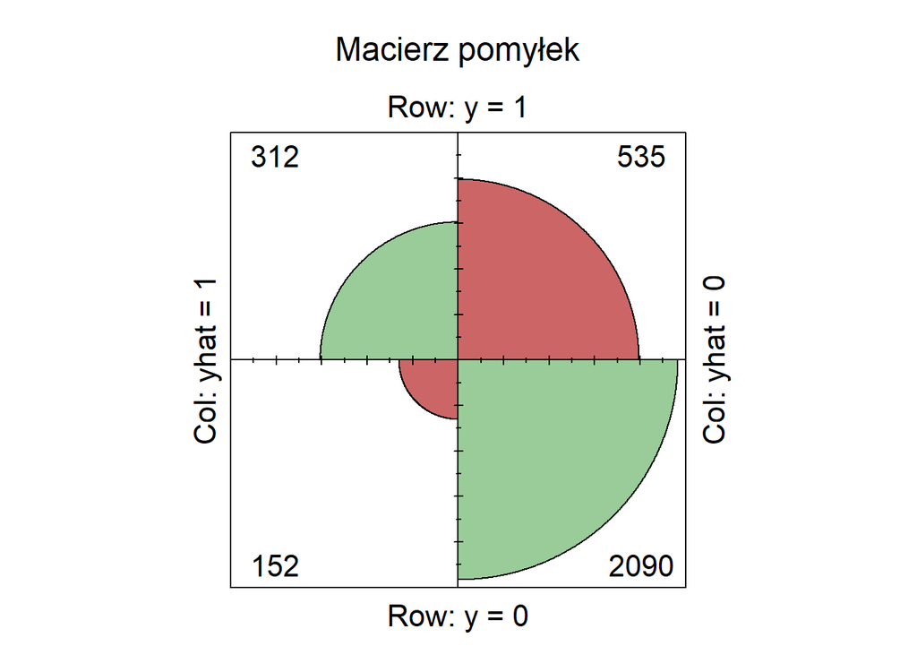

```r
conf_mat <- matrix(c(sum(true_pos), sum(false_pos),
                    sum(false_neg), sum(true_neg)), 2, 2)

colnames(conf_mat) <-c('yhat = 1', 'yhat = 0')
rownames(conf_mat) <- c('y = 1', 'y = 0')

fourfoldplot(conf_mat, color = c("#CC6666", "#99CC99"),conf.level = 0, margin = 1, main = "Macierz pomyłek")
```

### Miary na bazie macierzy pomyłek

**dokładność -** - iloraz sumy poprawnie sklasyfikowanych próbek przez sum wszystkich próbek. $\frac{TP+PN}{N}$  
**błąd -** iloraz sumy niepoprawnie sklasyfikowanych próbek przez sumę wszystkich $\frac{FP+FN}{N}$  
**czułość -** zdolność modelu do wychwytywania przypadków pozytywnych $\frac{PP}{PP+FN}$  
**swoistość -** zdolność modelu do wychwytywania przypadków negatywnych $\frac{PN}{FP+PN}$  
**PPV -** Wartość predykcyjną dodatnią opisuje zależność między liczbą wyników prawdziwie dodatnich (PP), a ogólną liczbą wyników dodatnich: prawdziwie dodatnich (PP) i fałszywie dodatnich (FP) $\frac{PP}{PP+FP}$  
**NPV -** Wartość predykcyjną ujemną opisuje zależność między liczbą wyników prawdziwie ujemnych (PN), a ogólną liczbą wyników ujemnych: prawdziwie ujemnych (PN) i fałszywie ujemnych (FN) $\frac{PN}{PN+FN}$: -

```r
accuracy <- (sum(true_pos) + sum(true_neg)) / (length(pred))

error <- (conf_mat[1, 2] + conf_mat[2,1]) / (length(pred))

recall <- conf_mat[1, 1] / (conf_mat[1,1]+ conf_mat[2,1])

specifity <- conf_mat[2, 2] / (conf_mat[1,2]+ conf_mat[2,2])

ppv <- 100*conf_mat[1,1]/(conf_mat[1,1]+ conf_mat[1,2])
npv <- 100*conf_mat[2,2]/(conf_mat[2,1]+ conf_mat[2,2])

df <- data.frame(matrix(ncol = 6, nrow = 0))
colnames(df) <- c('błąd', "dokładność", "czułość", 'specyficzność', 'PPV', 'NPV')
df[1,] = c(error, accuracy, recall, specifity, ppv,npv)
round(df,3)
```

```
##    błąd dokładność czułość specyficzność    PPV   NPV
## 1 0.222      0.778   0.672         0.796 36.836 93.22
```

### Krzywa ROC - Krzywa charakterystyki roboczej odbiornika

Krzywa rok pozwala zwizualizować skutecznośc klasyfikatora w oparciu o odsetek wskazań fałszywie pozytywnych oraz prawdziwie pozytywnych, wyliczanych poprzez przesunięcie progu decyzyjnego modelu regresji logistycznej(w tym przypadku).Przekątną krzywej rok możemy interpretować jako losowe zgadywanie klasyfikatora a skuteczność modeli klasyfikujących poniżej tej przekątnej jest uznawana za gorszą od zgadywania.

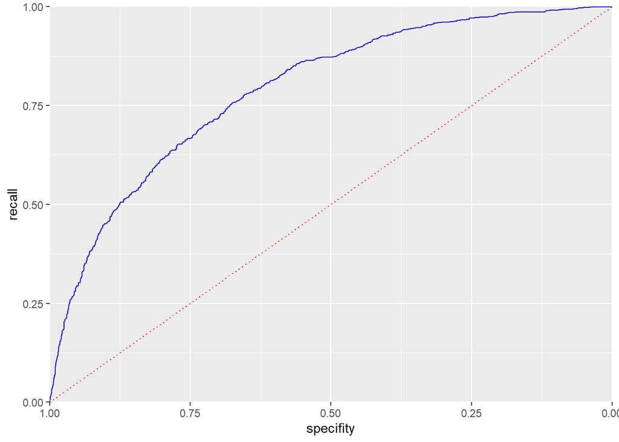

```r
idx <- order(-pred)
recall <- cumsum(true_y[idx]==1)/sum(true_y == 1)
specifity <- (sum(true_y == 0 ) - cumsum(true_y[idx] == 0)) / sum(true_y == 0)

roc_df <- data.frame(recall = recall, specifity=specifity)

ggplot(roc_df, aes(x=specifity, y=recall)) +
  geom_line(color='blue') +
  scale_x_reverse(expand = c(0, 0))+
  scale_y_continuous(expand=c(0,0))+
  geom_line(data=data.frame(x=(0:100)/100),
            aes(x=x, y=1-x),
            linetype='dotted',
            color='red')
```

### AUC - Area Under Curve Na podstawie krzywej ROC możemy obliczyć miarę wyrażającą skuteczność klasyfikatora. W przypadku ‘idealnego’ modelu wartość AUC wynosiłaby 1. W przypadku modelu całkowicie losowego, wartość ta wyniesie 0.5.

```r
sum(roc_df$recall[-1] * diff(1 - roc_df$specifity))
```

```
## [1] 0.7906175
```

**Wniosek**: Wartość AUC pozwala stwierdzić, że udało się uzyskać klasyfikator na akceptowalnym poziomie.

### Bootstrap

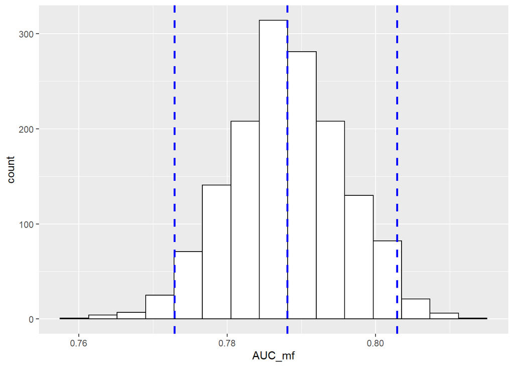

```r
AUC_mf <-c()
set.seed(NULL)
for (i in seq(1,1500,1)){

  n <- nrow(dane)
  liczby_losowe <- sample(c(1:n), round(0.7*n), replace = FALSE)

  dane_uczacy <- dane[liczby_losowe,]
  dane_testowy <- dane[-liczby_losowe,]

  mf <- glm(CLAIM_FLAG~INCOME+PARENT1+AGE_tr+HOME_VAL_D+CAR_USE+BLUEBOOK+TIF+REVOKED+URBANICITY+TRAVTIME:MVR_PTS,
             data = dane_uczacy, family = binomial)

  pred <- predict(mf, dane_testowy)

  pred_y <- as.numeric(pred > 0.0 )
  true_y <- as.numeric(dane_testowy$CLAIM_FLAG)-1

  idx <- order(-pred)
  recall <- cumsum(true_y[idx]==1)/sum(true_y == 1)
  specifity <- (sum(true_y == 0 ) - cumsum(true_y[idx] == 0)) / sum(true_y == 0)
  roc_df <- data.frame(recall = recall, specifity=specifity)

  AUC <- sum(roc_df$recall[-1] * diff(1 - roc_df$specifity))
  AUC_mf <- append(AUC_mf, AUC)
}

beta = 0.95
p = ((1.0-beta)/2.0)
lower <- max(0.0, quantile(unlist(AUC_mf), p))

p = (beta+ ((1.0-beta)/2.0))
upper = min(1.0, quantile(unlist(AUC_mf), p))

AUC_mf <- as.data.frame(AUC_mf)

##plot
ggplot(AUC_mf, aes(AUC_mf)) +
 geom_histogram(bins=15,colour="black", fill="white")+

  geom_vline(aes(xintercept=mean(unlist(AUC_mf))),
            color="blue", linetype="dashed", size=1) +

  geom_vline(aes(xintercept=lower),
            color="blue", linetype="dashed", size=1) +

  geom_vline(aes(xintercept=upper),
            color="blue", linetype="dashed", size=1)
```

```r
print(paste(beta*100,'% przedział ufności miary AUC:',
            round(lower*100,2), 'and', round(upper*100,2), 'ze średnią AUC:',round(mean(unlist(AUC_mf)),2)))
```

```
## [1] "95 % przedział ufności miary AUC: 77.29 and 80.29 ze średnią AUC: 0.79"
```